# Unveiling the Shadows of History: Exploring the Largest Dataset of Slave Records Online to Quantify the Human Toll of the Americas’ Slave Trade Industry

Frederick Jones

### Data Preparation

```r
library(tidyverse)
library(here)
```

### Abstract

The trafficking of enslaved Africans stands as a somber chapter in human history, leaving a lasting impact whose repercussions are felt even in contemporary times. The shadows cast by this dark period persist in the socio-cultural fabric of societies around the world. In an effort to shed light on the magnitude of this historical tragedy, our research project embarks on a comprehensive exploration of the largest dataset of slave records available online.

The primary objective of this undertaking is to delve into official documentation, meticulously examining and quantifying the total number of enslaved Africans who endured the harrowing journey across the Atlantic, bound for the Americas’ slave trade industry. By leveraging advanced data science methodologies, we aim to unveil the true extent of human suffering and displacement during this epoch.

The enormity of this historical injustice necessitates a rigorous and meticulous approach. Our investigation goes beyond the mere acknowledgment of the existence of enslaved individuals; it strives to provide a quantitative understanding of the scale of this transatlantic atrocity. Through careful analysis and calculation, we seek to offer a comprehensive assessment of the human toll exacted by the Americas’ slave trade industry.

As we navigate the vast expanse of historical records, we recognize the responsibility that comes with interpreting the narratives of those who endured unimaginable hardships. This project serves not only as a statistical endeavor but as a testament to the resilience and strength of those whose voices were silenced by the brutality of the slave trade. In quantifying the total number of enslaved Africans, we contribute to a broader understanding of this dark chapter, fostering awareness and acknowledgment of the profound impact it has left on the world we inhabit today.

### Cases

That that dataset has 11521 cases,each providing detailed information about the trafficking of enslaved.

Within this dataset, there are 126 variables, offering a comprehensive scope for analysis.

### Data collection

The dataset is hosted on the Slave Voyages website, a repository for historical information related to the transatlantic slave trade.

### Type of study

This is an observational study. It will analyze data collected from official documents and historical sources organized into a dataset.

Unfourtnaly, many informations are missing.

### Data Source

The data set has been made available by Slave Voyages at the following [link](https://www.slavevoyages.org/american/downloads#intra-american-database-downloads/0/en/)

### Dependent Variable

Two variables about number of slaves will be used. This variavbles will give us insights about how was the trafficking transported.

**tslavesd:**`Total slaves on board at departure from last slaving port` - numeric variable **slaarrivs:** `Total slaves arrived at first port of disembarkation` - numeric variable

### Independent Variable(s)

- **national**:`Country in which ship registered` - categorical variable
- **portdep**: `Port of departure` - categorical variable
- **majbuypt**: `Principal place of slave purchase` – categorical variable
- **majselpt**: `Principal port of slave disembarkation` – categorical variable
- **yearam**: `Year of arrival at port of disembarkation` - categorical variable

### Relevant summary statistics

## Load the required libraries

```r
library(tidyverse)
```

## Load the data

```r
data <- read.csv('I-Am1.0.csv')
head(data)
```

|  | IntraAmer | voyageid | yearam | rig | shipname | captaina | plac1tra | plac2tra | tslavesd | arrport | sla1port | slaarriv | sladvoy | vymrtimp | tslmtimp | vymrtrat | slaximp | slamimp | fate | fate2 | fate3 | fate4 | sladamer | adpsale1 | adpsale2 | captainb | placcons | placreg | yrcons | … |
| --- | --- | --- | --- | --- | --- | --- | --- | --- | --- | --- | --- | --- | --- | --- | --- | --- | --- | --- | --- | --- | --- | --- | --- | --- | --- | --- | --- | --- | --- | --- |
| 1 | 1 | 161000 | 1550 | NA |  |  | 39001 | NA | NA | 41210 | 41210 | 80 | NA | NA | NA | NA | 82 | 80 | 49 | 1 | 14 | 1 | NA | NA | NA |  | NA | NA | NA | … |
| 2 | 1 | 161001 | 1561 | NA |  | Baez, Pedro | 39001 | NA | NA | 41211 | 41211 | 100 | NA | NA | NA | NA | 102 | 100 | 49 | 1 | 14 | 1 | NA | NA | NA |  | NA | NA | NA | … |
| 3 | 1 | 161002 | 1561 | NA |  | Gomes, Antonio | 39001 | NA | NA | 41211 | 41211 | NA | NA | NA | NA | NA | 85 | 83 | 49 | 1 | 14 | 1 | NA | NA | NA |  | NA | NA | NA | … |
| 4 | 1 | 161003 | 1563 | NA |  | Gomes, Antonio | 39001 | NA | NA | 41215 | 41215 | 60 | NA | NA | NA | NA | 62 | 60 | 49 | 1 | 14 | 1 | NA | NA | NA |  | NA | NA | NA | … |
| 5 | 1 | 160600 | 1587 | NA | NS de Gracia |  | 50599 | NA | NA | 42001 | 42001 | 60 | NA | NA | NA | NA | 62 | 60 | 7 | 1 | 2 | 3 | NA | NA | NA |  | NA | NA | NA | … |
| 6 | 1 | 160601 | 1589 | NA | San Francisco |  | 50599 | NA | NA | 42001 | 42001 | 5 | NA | NA | NA | NA | 6 | 5 | 49 | 1 | 14 | 1 | NA | NA | NA |  | NA | NA | NA | … |

## Filtering the data for the slaves disembarked to the Americas

```r
library(dplyr)
data_America <- data|> filter(
   (fate2==1)
)
head(data_America)
```

|  | IntraAmer | voyageid | yearam | rig | shipname | captaina | plac1tra | plac2tra | tslavesd | arrport | sla1port | slaarriv | sladvoy | vymrtimp | tslmtimp | vymrtrat | slaximp | slamimp | fate | fate2 | fate3 | fate4 | sladamer | adpsale1 | adpsale2 | captainb | placcons | placreg | yrcons | … |
| --- | --- | --- | --- | --- | --- | --- | --- | --- | --- | --- | --- | --- | --- | --- | --- | --- | --- | --- | --- | --- | --- | --- | --- | --- | --- | --- | --- | --- | --- | --- |
| 1 | 1 | 161000 | 1550 | NA |  |  | 39001 | NA | NA | 41210 | 41210 | 80 | NA | NA | NA | NA | 82 | 80 | 49 | 1 | 14 | 1 | NA | NA | NA |  | NA | NA | NA | … |
| 2 | 1 | 161001 | 1561 | NA |  | Baez, Pedro | 39001 | NA | NA | 41211 | 41211 | 100 | NA | NA | NA | NA | 102 | 100 | 49 | 1 | 14 | 1 | NA | NA | NA |  | NA | NA | NA | … |
| 3 | 1 | 161002 | 1561 | NA |  | Gomes, Antonio | 39001 | NA | NA | 41211 | 41211 | NA | NA | NA | NA | NA | 85 | 83 | 49 | 1 | 14 | 1 | NA | NA | NA |  | NA | NA | NA | … |
| 4 | 1 | 161003 | 1563 | NA |  | Gomes, Antonio | 39001 | NA | NA | 41215 | 41215 | 60 | NA | NA | NA | NA | 62 | 60 | 49 | 1 | 14 | 1 | NA | NA | NA |  | NA | NA | NA | … |
| 5 | 1 | 160600 | 1587 | NA | NS de Gracia |  | 50599 | NA | NA | 42001 | 42001 | 60 | NA | NA | NA | NA | 62 | 60 | 7 | 1 | 2 | 3 | NA | NA | NA |  | NA | NA | NA | … |
| 6 | 1 | 160601 | 1589 | NA | San Francisco |  | 50599 | NA | NA | 42001 | 42001 | 5 | NA | NA | NA | NA | 6 | 5 | 49 | 1 | 14 | 1 | NA | NA | NA |  | NA | NA | NA | … |

## Find the number of slaves that arrived in the Americas and the number of slaves sold in the Americas.

```r
num_slave_arrived <- sum(data_America$slaarriv, na.rm = TRUE)
sprintf("Number of slave arrived in America : %d",num_slave_arrived)
```

```
## [1] "Number of slave arrived in America : 310383"
```

```r
slave_sold_America <- data_America|> filter(fate==49)|>
  summarize(
  "Number of unsold slaves in America" = sum(slaarriv, na.rm = TRUE ))
sprintf("The approximated number of slaves sold in America is %d",slave_sold_America$`Number of slaves sold in America`)
```

```
## character(0)
```

```r
unslaved<- num_slave_arrived - slave_sold_America
unslaved
```

| Number of unsold slaves in America |
| --- |
| 49330 |

```r
#Comments:
#The findings represents that the number of slave arrived in America is 310383 while the approximated number of slaves sold in America is 261053 and the difference is 49330 that is unslaved.
```

## Select the important columns related to slaves characteristics

```r
library(dplyr)
newData1 <- data_America[, c('tslavesd','national', 'slaximp','slaarriv','female1','child1', 'female3', 'child3', 'female7','child7','adult1', 'adult3', 'adult7')]
head(newData1)
```

|  | tslavesd | national | slaximp | slaarriv | female1 | child1 | female3 | child3 | female7 | child7 | adult1 | adult3 | adult7 |
| --- | --- | --- | --- | --- | --- | --- | --- | --- | --- | --- | --- | --- | --- |
| 1 | NA | NA | 82 | 80 | NA | NA | NA | NA | NA | NA | NA | NA | NA |
| 2 | NA | 4 | 102 | 100 | NA | NA | NA | NA | NA | NA | NA | NA | NA |
| 3 | NA | 4 | 85 | NA | NA | NA | NA | NA | NA | NA | NA | NA | NA |
| 4 | NA | 4 | 62 | 60 | NA | NA | NA | NA | NA | NA | NA | NA | NA |
| 5 | NA | 1 | 62 | 60 | NA | NA | NA | NA | NA | NA | NA | NA | NA |
| 6 | NA | 4 | 6 | 5 | NA | NA | NA | NA | NA | NA | NA | NA | NA |

```r
#Cleaned the newdata
newData <- data_America[, c('slaximp','slaarriv')]
head(newData)
```

|  | slaximp | slaarriv |
| --- | --- | --- |
| 1 | 82 | 80 |
| 2 | 102 | 100 |
| 3 | 85 | NA |
| 4 | 62 | 60 |
| 5 | 62 | 60 |
| 6 | 6 | 5 |

```r
#Comments: In the newdata1, we found that there are 'NA' in tslavesed and female1 and in other variables, we did not see any value such as when we look at the first row,it's found that 82 slaves imputed and out of 82 only 80 disembarked on Americas ports. But the proportion of adults, children and women among them are not given. SO, that is why we  only find number of slaves arrived in America and total number of slaves imputed and that is represent as newData.
```

# Linear Regression analysis

```r
reg<-lm(slaarriv~slaximp, data = data)
summary(reg)
```

```
##
## Call:
## lm(formula = slaarriv ~ slaximp, data = data)
##
## Residuals:
##      Min       1Q   Median       3Q      Max
## -194.833   -0.183   -0.060    0.302    9.358
##
## Coefficients:
##               Estimate Std. Error t value Pr(>|t|)
## (Intercept) -0.7459020  0.0495274  -15.06   <2e-16 ***
## slaximp      0.9823157  0.0005631 1744.52   <2e-16 ***
## ---
## Signif. codes:  0 '***' 0.001 '**' 0.01 '*' 0.05 '.' 0.1 ' ' 1
##
## Residual standard error: 3.581 on 7108 degrees of freedom
##   (4411 observations deleted due to missingness)
## Multiple R-squared:  0.9977, Adjusted R-squared:  0.9977
## F-statistic: 3.043e+06 on 1 and 7108 DF,  p-value: < 2.2e-16
```

```r
#Comments:The findings shows that the p-value of slaximp is <2e-16 that is less than 0.05 so, we can conclude that there is a statistically significant impact of the number of slaves imputed(independent variable) on the number of slaves arrived in America(dependent variable).
```

# Visualization

```r
library(ggplot2)
summary_slaves<-newData|>reframe(
  Slave_Status = c("Embarked","Arrived in America"),
  Number_of_Slaves = c(sum(slaximp, na.rm = TRUE), sum(slaarriv, na.rm = TRUE))
  )
summary_slaves
```

| Slave_Status | Number_of_Slaves |
| --- | --- |
| Embarked | 455193 |
| Arrived in America | 310383 |

```r
#Comments: The findings represents that there are total 455193 number of slaves who were initially embarked on ships and there are 310383 subset of slaves who successfully arrived in America. The difference between Embarked and Arrived in America is 144,810 which means there are 144,810 number of slaves who did not arrive in America.
```

## Visualization

```r
require(scales)
```

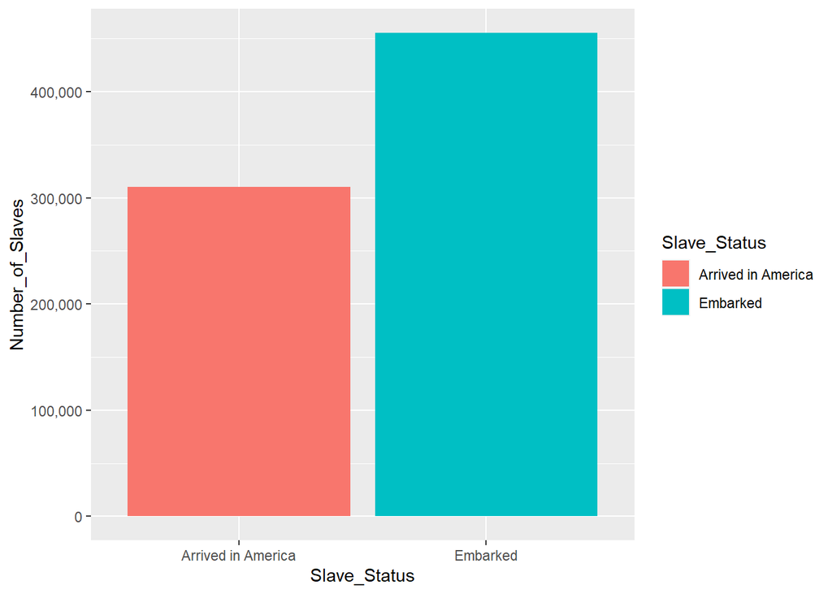

```r
ggplot(data = summary_slaves, aes(x=Slave_Status, y=Number_of_Slaves, fill=Slave_Status))+
  geom_col()+
  scale_y_continuous(labels = scales::comma)
```

```r
#Comments: The figure represents that number of slaves are higher in those who were initially embarked on ships while there are less number of slaves who arrived in america.
```

## Gender wise slaves and number of children among the slaves.

```r
slaves_Gend_dis<-newData1|>reframe(
  Slave_Status = c("Male", "Females","Children"),
  Number_of_Slaves = c( sum(slaarriv, na.rm = TRUE)
                        -round((sum(female7, na.rm = TRUE))),
                       round(sum(female7, na.rm = TRUE)),
                       round(sum(child7, na.rm = TRUE)) )
  )
slaves_Gend_dis
```

| Slave_Status | Number_of_Slaves |
| --- | --- |
| Male | 292676 |
| Females | 17707 |
| Children | 22706 |

```r
#Comments: The findings revealed that there are 292676 male salves, 17707 female slaves and 22706   children who are slaves. And it can be seen that the males number of slaves are higher than females and children.
```

# Merge country code with country name

```r
national <- c(1, 2, 4, 5, 7, 8, 9, 10, 11, 12, 13, 14, 16, 17, 18, 19, 24, 25, 26, 27)
country<- c("Spain", "Uruguay", "Portugal", "Brazil", "Great Britain", "Netherlands", "U.S.A.",
             "France", "Denmark", "Hanse Towns, Brandenburg", "Sweden", "Norway", "Argentina",
             "Russia", "Sardinia", "Mexico", "Genoa", "Duchy of Courland", "Prussia", "Bremen")
countryData <- data.frame(national = national, own_country = country)
head(countryData)
```

|  | national | own_country |
| --- | --- | --- |
| 1 | 1 | Spain |
| 2 | 2 | Uruguay |
| 3 | 4 | Portugal |
| 4 | 5 | Brazil |
| 5 | 7 | Great Britain |
| 6 | 8 | Netherlands |

```r
#Comments: It can be seen that the country code with country name.
```

# Merge ship data with national

```r
ships_data<-newData1|> reframe(
  Nation =  c("Spain", "Uruguay", "Portugal", "Brazil", "Great Britain", "Netherlands", "U.S.A.",
             "France", "Denmark", "Hanse Towns, Brandenburg", "Sweden", "Norway", "Argentina",
             "Russia", "Sardinia", "Mexico", "Genoa", "Duchy of Courland", "Prussia", "Bremen", 'NA'),
  Number_of_Ships = c(sum(national==1, na.rm = TRUE), sum(national==2, na.rm = TRUE),
                      sum(national==4, na.rm = TRUE), sum(national==5, na.rm = TRUE),
                      sum(national==7, na.rm = TRUE), sum(national==8, na.rm = TRUE),
                      sum(national==9, na.rm = TRUE), sum(national==10, na.rm = TRUE),
                      sum(national==11, na.rm = TRUE), sum(national==12, na.rm = TRUE),
                      sum(national==13, na.rm = TRUE), sum(national==14, na.rm = TRUE),
                      sum(national==16, na.rm = TRUE), sum(national==17, na.rm = TRUE),
                      sum(national==18, na.rm = TRUE), sum(national==19, na.rm = TRUE),
                      sum(national==24, na.rm = TRUE), sum(national==25, na.rm = TRUE),
                      sum(national==26, na.rm = TRUE), sum(national==27, na.rm = TRUE),
                      sum(is.na(national)))
)
ships_data
```

| Nation | Number_of_Ships |
| --- | --- |
| Spain | 1479 |
| Uruguay | 0 |
| Portugal | 351 |
| Brazil | 0 |
| Great Britain | 3905 |
| Netherlands | 63 |
| U.S.A. | 861 |
| France | 385 |
| Denmark | 247 |
| Hanse Towns, Brandenburg | 0 |

[output cut: 11 more lines]

```r
#Comments: The findings tell that 3905 number of ships trading slaves are registered in the Great Britain. US registered number of ships involved in slave trade are 861,which is less than Great Britain. It can also be seen that 1479 number of ships trading slaves are registered in the Spain that is on second number.
```

# Visualization

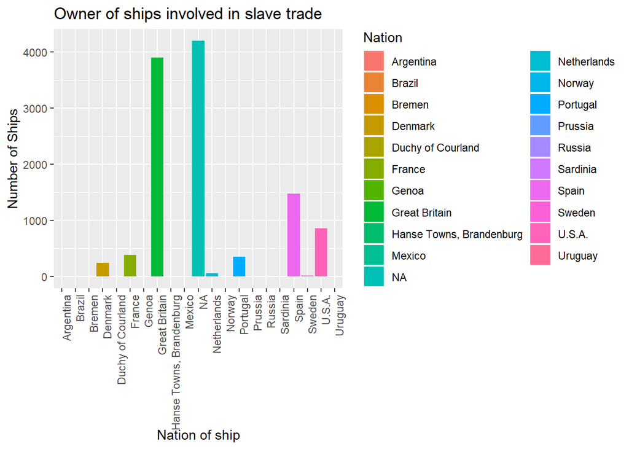

```r
require(scales)
ggplot(data = ships_data, aes(x=Nation, y= Number_of_Ships, fill=Nation))+
  geom_col()+
  theme(axis.text.x = element_text(angle = 90, hjust=1))+
  labs(title = "Owner of ships involved in slave trade",
       y ="Number of Ships",
       x = "Nation of ship")
```

```r
#Comments: The graph is also representing that Great Britain number of ships are on top carrier of slaves, after that Spain and at last US. These number of ships forcefully captured people and traded them in these countries.
```

# Ships with slaves captured by the US and Greater Britain, Spain, France. To do this, the following information is useful:

fate =11 => Captured by British (after embarkation of slaves) fate =15 => Captured by Spanish (after embarkation of slaves) fate =51 => Captured by French (after embarkation of slaves) fate =161 => Captured by USA (after embarkation of slaves)

```r
data|> group_by(fate)|>
  summarize(
    total_ship = n())|>
  filter(
    fate==11 | fate ==15 | fate == 51 | fate == 161
  )
```

| fate | total_ship |
| --- | --- |
| 11 | 4 |
| 15 | 5 |
| 51 | 2 |
| 161 | 4 |

```r
#Comments: It can also be seen that how many Ships with slaves captured by the US and Greater Britain, Spain, France. The results shows that there are only 4 ships with slaves captured by British, 5 ships with slave captured by Spanish, 2 ships with slaves captured by French and only 4 ships with slaves captured by USA.
```

## Total number of slaves arrived in America is the total number of slaves in the variable ‘slaarriv’

This can be done using the sum() but there are na values in the column ‘slaarriv’ so we have to use na.rm=TRUE inside sum()

```r
num_slave_arrived <- sum(newData$slaarriv, na.rm = TRUE)
sprintf("Number of slaves that arrived in the Americas using the data are %d", num_slave_arrived)
```

```
## [1] "Number of slaves that arrived in the Americas using the data are 310383"
```

```r
#Comments: It can be seen that there are 310383 Number of slaves arrived in America using the data.
```